# railwayJP

## Overview

`railwayJP` is an R package for creating maps of railway routes across Japan.

It uses the National Land Numerical Information (Railway Data) from the Ministry of Land, Infrastructure, Transport and Tourism (MLIT).

## Web Application

A web-based version of this tool is available at: **https://soichiroy.github.io/railwayJP-web/**

> **Note**: The web application is currently in development. Some features may be incomplete or subject to change.

## Installation

```r
# Install from GitHub
# devtools::install_github("soichiroy/railwayJP")
```

## Quick Start

### 1. Download the data

The railway data is not included in the package due to size (~20MB). Download it on first use:

```r
download_railway_data()
```

```
#> Railway data already exists at: ~/Library/Caches/railwayJP/UTF-8
#> Use force = TRUE to re-download
```

### 2. Plot a simple route

```
#> Loading railway data...
#> Data loaded: 21916 railroad sections, 10220 stations
#>
#> Processing segment 1 : All lines 松山 -> 高松
#>   Using 559 sections, 271 station records
#>   Building track graph...
#>     Nodes: 541 Sections: 559
#>   Waypoints: 松山 -> 高松
#>   Finding path from 松山 to 高松 ...
#>     Found 117 sections
#>   Total path sections: 117
#>   Route: 松山 -> 三津浜 -> 伊予和気 -> 堀江 -> 光洋台 -> 粟井 -> 柳原 -> 伊予北条 -> 大浦 -> 浅海 -> 菊間 -> 伊予亀岡 -> 大西 -> 伊予三芳 -> 伊予富田 -> 伊予桜井 -> 壬生川 -> 玉之江 -> 波方 -> 今治 -> 伊予小松 -> 波止浜 -> 伊予氷見 -> 石鎚山 -> 伊予西条 -> 中萩 -> 新居浜 -> 多喜浜 -> 関川 -> 伊予土居 -> 赤星 -> 伊予寒川 -> 伊予三島 -> 川之江 -> 箕浦 -> 豊浜 -> 観音寺 -> 本山 -> 比地大 -> 高瀬 -> 詫間 -> みの -> 津…
#>   Result: 117 sections, 58 stations
#>
#> Map saved to man/figures/matsuyama_takamatsu.png
```

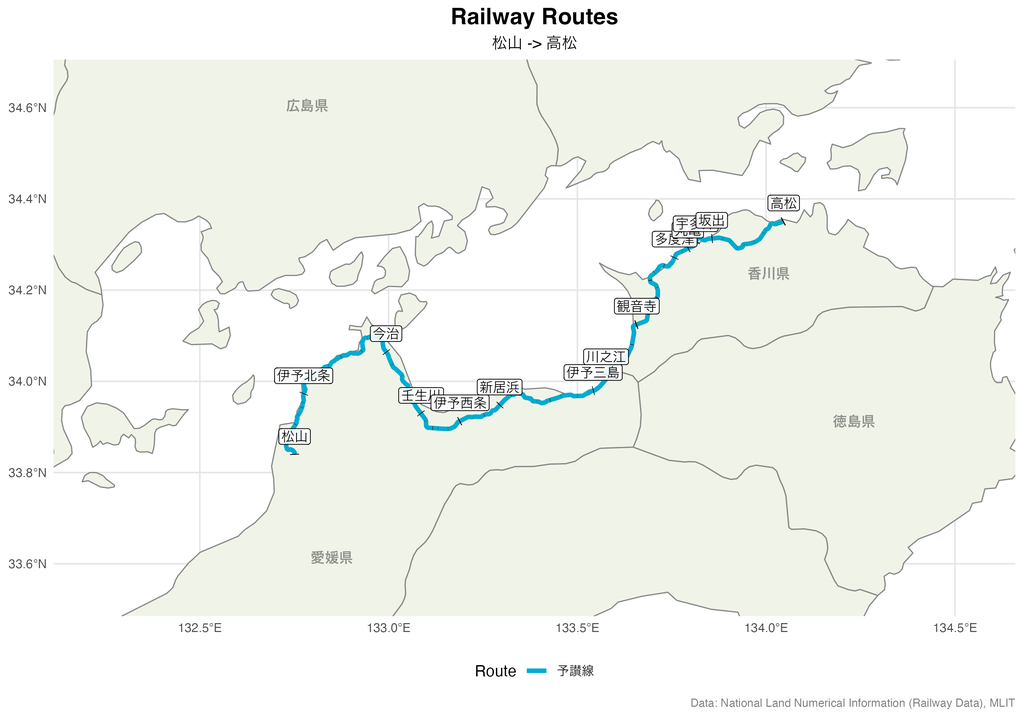

Matsuyama to Takamatsu route

```r
plot_railway_segments(
  segments = list(
    list(start = "松山", end = "高松", operator = "四国旅客鉄道", label = "予讃線")
  ),
  key_stations = c(
    "高松", "坂出", "宇多津", "丸亀", "多度津", "観音寺", "川之江", "伊予三島", "新居浜",
    "伊予西条", "壬生川", "今治", "伊予北条", "松山"
  ),
  output_file = "man/figures/matsuyama_takamatsu.png",
  width = 10,
  height = 7,
  dpi = 300
)
```

- `key_stations`: An optional parameter that allows highlighting specific stations with labels along the route.

#### Tips: Specifying operator and line names

It is important to provide accurate operator and line names to avoid ambiguity when the origin or destination stations are served by multiple lines.

```r
routes <- get_route(
  list(
    # Does not specify operator - return routes that include multiple lines
    list(start = "松山", end = "三津浜"),
    # Specify operator to get a unique route
    list(start = "松山", end = "三津浜", operator = "四国旅客鉄道")
  )
)
```

```
#>
#> [1] 松山 -> 三津浜
#>   Filter: All lines
#>   Available: 21916 sections, 10220 stations
#>   Building track graph...
#>     Nodes: 20608 Sections: 21916
#>   Waypoints: 松山 -> 三津浜
#>   Finding path from 松山 to 三津浜 ...
#>     Found 1 sections
#>   Total path sections: 1
#>   Route: 松山 -> ＪＲ松山駅前 -> 宮田町 -> 衣山 -> 西衣山 -> 三津浜
#>   Result: 1 sections, 6 stations
#>
#> [2] 松山 -> 三津浜
#>   Filter: All lines (四国旅客鉄道)
#>   Available: 559 sections, 271 stations
#>   Building track graph...
#>     Nodes: 541 Sections: 559
#>   Waypoints: 松山 -> 三津浜
#>   Finding path from 松山 to 三津浜 ...
#>     Found 1 sections
#>   Total path sections: 1
#>   Route: 松山 -> 三津浜
#>   Result: 1 sections, 2 stations
```

- In the first example, without specifying an operator, the algorithm finds a route that includes segments from 伊予鉄道 (Iyo Railway). However, there is no direct connection between 西衣山 and 三津浜 on this route.
- In the second example, by specifying `operator = "四国旅客鉄道"` (JR Shikoku), the algorithm correctly identifies the 予讃線 (Yosan Line) route.

### 3. Plot multiple routes with via points

The function supports a segment that spans over multiple lines. For example, going from 新宿 to 長野 using 在来線, we need to transfer at 松本.

```
#>
#> Processing segment 1 : All lines 新宿 -> 長野
#>   Using 4146 sections, 1802 station records
#>   Building track graph...
#>     Nodes: 3818 Sections: 4146
#>   Waypoints: 新宿 -> 松本 -> 長野
#>   Finding path from 新宿 to 松本 ...
#>     Found 166 sections
#>   Finding path from 松本 to 長野 ...
#>     Found 26 sections
#>   Total path sections: 192
#>   Route: 新宿 -> 大久保 -> 新大久保 -> 東中野 -> 中野 -> 高円寺 -> 阿佐ヶ谷 -> 荻窪 -> 西荻窪 -> 吉祥寺 -> 三鷹 -> 武蔵境 -> 東小金井 -> 武蔵小金井 -> 国分寺 -> 西国分寺 -> 国立 -> 立川 -> 日野 -> 豊田 -> 八王子 -> 西八王子 -> 高尾 -> 相模湖 -> 藤野 -> 上野原 -> 四方津 -> 梁川 -> 鳥沢 -> 猿橋 -> 大月 -> 初狩 -> 笹子 -> 甲斐大和 -> 勝沼ぶどう郷 -> 塩山 -> 東山梨 -> 山梨市 -> 春日居町 -> 石和温泉 -> 酒折 -> 甲府 -> …
#>   Result: 192 sections, 72 stations
#>
#> Map saved to man/figures/railway_routes.png
```

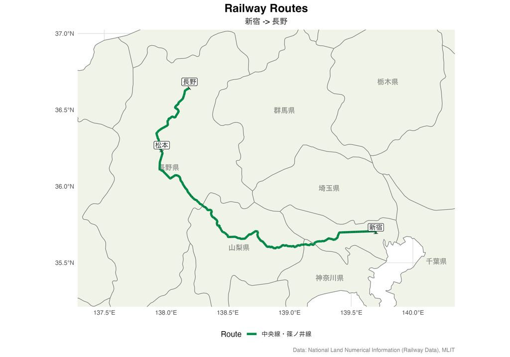

```r
plot_railway_segments(
  segments = list(
    # Route via Matsumoto (Chuo Line) instead of Shinkansen
    list(
      start = "新宿",
      end = "長野",
      via = c("松本"),
      operator = "東日本旅客鉄道",
      label = "中央線・篠ノ井線"
    )
  ),
  title = "Railway Routes",
  key_stations = c("新宿", "松本", "長野"),
  show_legend = TRUE,
  output_file = "man/figures/railway_routes.png",
  width = 10,
  height = 7,
  dpi = 300
)
```

### 4. Multiple independent routes

You can plot multiple independent routes on the same map by providing multiple segments.

```
#>
#> Processing segment 1 : All lines 松山 -> 岡山
#>   Using 3404 sections, 1557 station records
#>   Building track graph...
#>     Nodes: 3188 Sections: 3404
#>   Waypoints: 松山 -> 児島 -> 岡山
#>   Finding path from 松山 to 児島 ...
#>     Found 98 sections
#>   Finding path from 児島 to 岡山 ...
#>     Found 22 sections
#>   Total path sections: 120
#>   Route: 松山 -> 三津浜 -> 伊予和気 -> 堀江 -> 光洋台 -> 粟井 -> 柳原 -> 伊予北条 -> 大浦 -> 浅海 -> 菊間 -> 伊予亀岡 -> 大西 -> 伊予三芳 -> 伊予富田 -> 伊予桜井 -> 壬生川 -> 玉之江 -> 波方 -> 今治 -> 伊予小松 -> 波止浜 -> 伊予氷見 -> 石鎚山 -> 伊予西条 -> 中萩 -> 新居浜 -> 多喜浜 -> 関川 -> 伊予土居 -> 赤星 -> 伊予寒川 -> 伊予三島 -> 川之江 -> 箕浦 -> 豊浜 -> 観音寺 -> 本山 -> 比地大 -> 高瀬 -> 詫間 -> みの -> 津…
#>   Result: 120 sections, 60 stations
#>
#> Processing segment 2 : 山陽新幹線 岡山 -> 新神戸
#>   Using 46 sections, 20 station records
#>   Building track graph...
#>     Nodes: 46 Sections: 46
#>   Waypoints: 岡山 -> 新神戸
#>   Finding path from 岡山 to 新神戸 ...
#>     Found 8 sections
#>   Total path sections: 8
#>   Route: 岡山 -> 相生 -> 姫路 -> 西明石 -> 新神戸
#>   Result: 8 sections, 5 stations
#>
#> Processing segment 3 : All lines 名古屋 -> 富山
#>   Using 3876 sections, 1725 station records
#>   Building track graph...
#>     Nodes: 3606 Sections: 3876
#>   Waypoints: 名古屋 -> 岐阜 -> 高山 -> 富山
#>   Finding path from 名古屋 to 岐阜 ...
#>     Found 15 sections
#>   Finding path from 岐阜 to 高山 ...
#>     Found 54 sections
#>   Finding path from 高山 to 富山 ...
#>     Found 39 sections
#>   Total path sections: 107
#>   Route: 名古屋 -> 枇杷島 -> 清洲 -> 稲沢 -> 尾張一宮 -> 木曽川 -> 蘇原 -> 那加 -> 鵜沼 -> 各務ケ原 -> 長森 -> 岐阜 -> 坂祝 -> 美濃太田 -> 古井 -> 中川辺 -> 下麻生 -> 上麻生 -> 白川口 -> 下油井 -> 飛騨金山 -> 焼石 -> 下呂 -> 禅昌寺 -> 飛騨萩原 -> 上呂 -> 飛騨宮田 -> 飛騨小坂 -> 渚 -> 久々野 -> 飛騨一ノ宮 -> 高山 -> 上枝 -> 飛騨国府 -> 飛騨古川 -> 杉崎 -> 飛騨細江 -> 角川 -> 坂上 -> 打保 -> 杉原 -> 猪谷 -> 楡原 -…
#>   Result: 107 sections, 51 stations
#>
#> Map saved to man/figures/multiple_routes.png
```

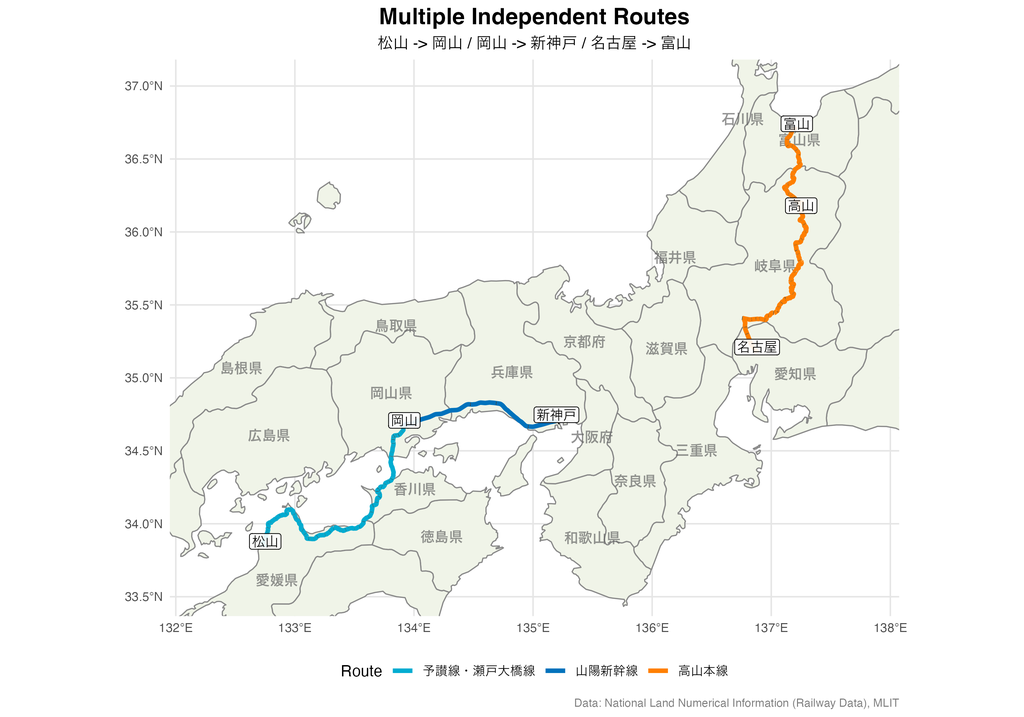

Multiple independent routes

```r
plot_railway_segments(
  segments = list(
    # Route 1: Matsuyama to Shin-Kobe
    list(
      start = "松山",
      end = "岡山",
      via = "児島",
      label = "予讃線・瀬戸大橋線",
      operator = c("四国旅客鉄道", "西日本旅客鉄道")
    ),
    list(
      start = "岡山",
      end = "新神戸",
      line = "山陽新幹線",
      label = "山陽新幹線"
    ),
    # Route 2: Nagoya to Toyama via Takayama Line
    list(
      start = "名古屋",
      end = "富山",
      via = c("岐阜", "高山"),
      operator = c("東海旅客鉄道", "西日本旅客鉄道"),
      label = "高山本線"
    )
  ),
  title = "Multiple Independent Routes",
  key_stations = c("松山", "岡山", "新神戸", "名古屋", "高山", "富山"),
  show_legend = TRUE,
  output_file = "man/figures/multiple_routes.png",
  width = 10,
  height = 7,
  dpi = 300
)
```

#### Tips: Visualizing a long route across multiple operators

When visualizing a long route that spans multiple operators, you can approximate the route by specifying intermediate stops using the `via` argument.

For example, back in 2008 I took local trains from 京都 to 新潟 via the 北陸本線, which was solely operated by JR at the time. Visualizing this route is tricky because it is now operated by multiple third-party companies.

```
#>
#> Processing segment 1 : All lines 京都 -> 直江津
#>   Using 21916 sections, 10220 station records
#>   Building track graph...
#>     Nodes: 20608 Sections: 21916
#>   Waypoints: 京都 -> 比叡山坂本 -> 敦賀 -> 福井 -> 金沢 -> 富山 -> 黒部 -> 糸魚川 -> 直江津
#>   Finding path from 京都 to 比叡山坂本 ...
#>     Found 10 sections
#>   Finding path from 比叡山坂本 to 敦賀 ...
#>     Found 46 sections
#>   Finding path from 敦賀 to 福井 ...
#>     Found 24 sections
#>   Finding path from 福井 to 金沢 ...
#>     Found 39 sections
#>   Finding path from 金沢 to 富山 ...
#>     Found 3 sections
#>   Finding path from 富山 to 黒部 ...
#>     Found 13 sections
#>   Finding path from 黒部 to 糸魚川 ...
#>     Found 19 sections
#>   Finding path from 糸魚川 to 直江津 ...
#>     Found 20 sections
#>   Total path sections: 174
#>   Route: 京都 -> 京阪山科 -> 山科 -> 四宮 -> 京阪大津京 -> 大津京 -> 滋賀里 -> 唐崎 -> 比叡山坂本 -> おごと温泉 -> 堅田 -> 小野 -> 和邇 -> 蓬莱 -> 志賀 -> 比良 -> 近江舞子 -> 北小松 -> 近江高島 -> 安曇川 -> 新旭 -> 近江今津 -> 近江中庄 -> マキノ -> 永原 -> 近江塩津 -> 新疋田 -> 敦賀 -> 南今庄 -> 今庄 -> 湯尾 -> 南条 -> 王子保 -> 武生 -> 越前武生 -> スポーツ公園 -> 家久 -> 鯖江 -> 北鯖江 -> 大土呂 -> 越前花堂 -> 花堂 …
#>   Result: 174 sections, 113 stations
#>
#> Map saved to man/figures/hokuriku_line.png
```

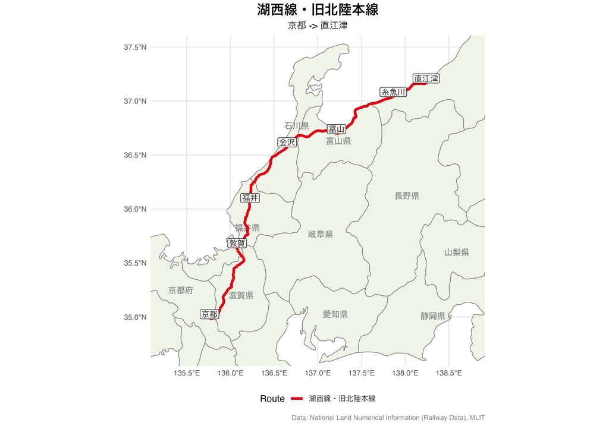

```r
plot_railway_segments(
  segments = list(
    list(
      start = "京都",
      end = "直江津",
      via = c("比叡山坂本", "敦賀", "福井", "金沢", "富山", "黒部", "糸魚川"),
      label = "湖西線・旧北陸本線"
    )
  ),
  title = "湖西線・旧北陸本線",
  key_stations = c("京都", "敦賀", "福井", "金沢", "富山", "糸魚川", "直江津"),
  show_legend = TRUE,
  output_file = "man/figures/hokuriku_line.png",
  width = 10,
  height = 7,
  dpi = 300
)
```

While the detected route is not perfect, the visual line on the map captures key topological features of the route.

## Segment Options

Each segment in the `segments` list can have the following options:

| Option | Required | Description |
| --- | --- | --- |
| `start` | Yes | Start station name (use `search_stations()` to find names) |
| `end` | Yes | End station name |
| `via` | No | Character vector of intermediate stations |
| `line` | No | Filter to specific line name, e.g., `"東海道線"` or `"東海道新幹線"` (use `search_lines()` to find names) |
| `operator` | No | Filter to specific operator (use `list_operators()` to see all) |
| `color` | No | Custom color (hex code) |
| `label` | No | Label for legend |

Use `search_lines()` to find the exact line name:

```r
search_lines("東海道")
```

```
#>           line       operator n_sections n_stations
#> 1 東海道新幹線   東海旅客鉄道         44         17
#> 2     東海道線 東日本旅客鉄道        125         37
#> 3     東海道線   東海旅客鉄道        231         86
#> 4     東海道線 西日本旅客鉄道        130         52
```

## Plot Options

| Option | Default | Description |
| --- | --- | --- |
| `output_file` | “railway_map.png” | Output filename |
| `title` | “Railway Routes” | Plot title |
| `subtitle` | (auto) | Plot subtitle |
| `show_all_stations` | TRUE | Show all stations along routes |
| `key_stations` | NULL | Stations to highlight with labels |
| `show_legend` | TRUE | Show route legend |
| `width` | 14 | Plot width (inches) |
| `height` | 10 | Plot height (inches) |
| `dpi` | 300 | Output resolution |

## Utility Functions

```r
# List all railway lines
list_lines()

# Search for lines by name
list_lines("中央")

# List stations on a line
list_stations("中央線", operator = "東日本旅客鉄道")

# Search for stations
search_stations("新宿")

# List all operators
list_operators()

# Get data info
get_data_info()
```

## Operator Colors

The package includes corporate colors for major Japanese railway operators:

```r
# View all operator colors
list_operator_colors()

# Get color for specific operator
get_operator_color("東日本旅客鉄道")
```

```r
# JR East green
railwayJP::get_operator_color("東日本旅客鉄道")
```

```
#> [1] "#008C4A"
```

## Data Source

This package uses the National Land Numerical Information (Railway Data) from MLIT:

- **URL**: https://nlftp.mlit.go.jp/ksj/
- **Data version**: N02-22 (2022)
- **License**: MLIT Open Data License (allows redistribution and commercial use)
- **Attribution required**: “Source: National Land Numerical Information (Railway Data), MLIT”

## License

MIT License

The railway data is provided under the MLIT Open Data License, which permits reproduction, redistribution, commercial use, and derivative works with attribution.